# DeepTweets

### Binary Classification task for tweets

This is a tweet classification task where the tweets could be either Politics or Sports

Let's get Started!!!

Downloading nltk data

```
True
```

### Dataset Description

The dataset comprises two CSV files, one designated for training and the other for testing, each containing crucial information related to tweets.

The primary fields in both files include "TweetId" serving as an anonymous and unique identifier for each tweet and "TweetText" encapsulating the textual content of each tweet. The "Label" field which categorizes the tweets into two distinct classes: Sports or Politics, is only present in the training file

This dataset serves as a valuable resource for training and evaluating our model which aim at classifying tweets based on their content.

### Data Exploration

A quick look to the Training and Test set shape

```
(6525, 3)
(2610, 2)
```

An overview of the training set

|  | TweetId | Label | TweetText |
| --- | --- | --- | --- |
| 0 | 304271250237304833 | Politics | '#SecKerry: The value of the @StateDept and @U... |
| 1 | 304834304222064640 | Politics | '@rraina1481 I fear so' |
| 2 | 303568995880144898 | Sports | 'Watch video highlights of the #wwc13 final be... |
| 3 | 304366580664528896 | Sports | 'RT @chelscanlan: At Nitro Circus at #AlbertPa... |
| 4 | 296770931098009601 | Sports | '@cricketfox Always a good thing. Thanks for t... |

An overview of the Test set

|  | TweetId | TweetText |
| --- | --- | --- |
| 0 | 306486520121012224 | '28. The home side threaten again through Maso... |
| 1 | 286353402605228032 | '@mrbrown @aulia Thx for asking. See http://t.... |
| 2 | 289531046037438464 | '@Sochi2014 construction along the shores of t... |
| 3 | 306451661403062273 | '#SecKerry\u2019s remarks after meeting with F... |
| 4 | 297941800658812928 | 'The #IPLauction has begun. Ricky Ponting is t... |

Plotting the Distribution of the classes in the Training set

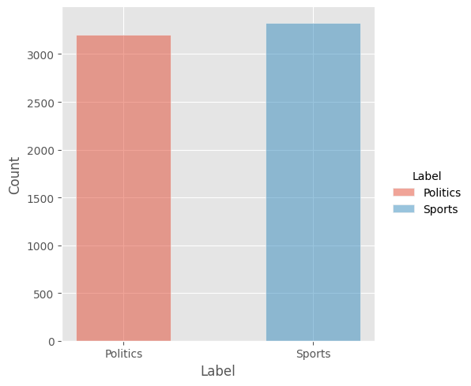

### Data Preprocessing

Checking for missing values

```
TweetId      0
Label        0
TweetText    0
dtype: int64
```

```
TweetId      0
TweetText    0
dtype: int64
```

Applying the Pre-processing method to the training and test set. This method add a new field to the dataframes which contains the result of several transformation on the Tweet Text.

Showing the result of the preprocessing on the Training set

|  | Label | TweetText | ProcessedText |
| --- | --- | --- | --- |
| 0 | Politics | '#SecKerry: The value of the @StateDept and @U... | seckerry value statedept usaid measured dollar... |
| 1 | Politics | '@rraina1481 I fear so' | fear |
| 2 | Sports | 'Watch video highlights of the #wwc13 final be... | video highlight final australia west indie http |
| 3 | Sports | 'RT @chelscanlan: At Nitro Circus at #AlbertPa... | chelscanlan nitro circus albertpark theymakeit... |
| 4 | Sports | '@cricketfox Always a good thing. Thanks for t... | cricketfox always good thing thanks feedback |
| ... | ... | ... | ... |
| 6520 | Politics | 'Photo: PM has laid a wreath at Martyrs Monume... | pm ha laid wreath martyr monument algiers http... |
| 6521 | Sports | 'The secret of the Chennai pitch - crumbling o... | secret chennai pitch crumbling edge solid midd... |
| 6522 | Sports | @alinabhutto he isn't on Twitter either | alinabhutto twitter either |
| 6523 | Sports | 'Which England player would you take out to di... | england player would take dinner featuring amp... |
| 6524 | Politics | 'Dmitry #Medvedev expressed condolences to the... | medvedev expressed condolence family friend co... |

6525 rows × 3 columns

Splitting the training set for evaluation

### Creating our Naive Bayes classifier

### Evaluation of the classifier

Displaying a confusion matrix

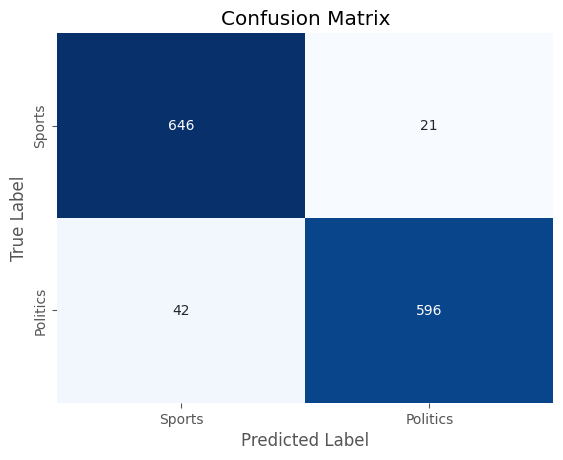

Print classifaction report

```
              precision    recall  f1-score   support

    Politics       0.97      0.93      0.95       638
      Sports       0.94      0.97      0.95       667

    accuracy                           0.95      1305
   macro avg       0.95      0.95      0.95      1305
weighted avg       0.95      0.95      0.95      1305
```

#### Classifying the Tweets in the test set

|  | TweetText | PredictedLabel |
| --- | --- | --- |
| 0 | '28. The home side threaten again through Maso... | Sports |
| 1 | '@mrbrown @aulia Thx for asking. See http://t.... | Politics |
| 2 | '@Sochi2014 construction along the shores of t... | Politics |
| 3 | '#SecKerry\u2019s remarks after meeting with F... | Politics |
| 4 | 'The #IPLauction has begun. Ricky Ponting is t... | Sports |
| ... | ... | ... |
| 2605 | 'Qualifier 1 and Eliminator games will be play... | Sports |
| 2606 | @reesedward Hi Edward, it's not a #peacekeepin... | Sports |
| 2607 | 'Perera was @SunRisersIPL first #IPL purchase ... | Sports |
| 2608 | '#SecKerry: Thanks to Senator @TimKaine, @RepR... | Politics |
| 2609 | Here's a picture from our official Pinterest a... | Politics |

2610 rows × 2 columns